# BDCD Business Analytics Lab Exercise

Prof Di Cook, Steph Kobakian, Stuart Lee, Nick Spyrison

Econometrics & Bus Stat, Monash, Clayton campus, 22/2/2019

## Links to reading

https://compare.energy.vic.gov.au

http://www.smartmeters.vic.gov.au/#

[https://www.computerworld.com](https://www.computerworld.com/article/2497143/business-intelligence/business-intelligence-beginner-s-guide-to-r-introduction.html)

https://github.com/Monash-BDCD/energy

## Exercise 1: Background work

Read in Di’s energy data. Look at the format of the data, and then rearrange it to a tidier format.

```
## # A tibble: 3 x 7
##   id    date        d1    d2    d3    d4    d5
##   <chr> <chr>    <dbl> <dbl> <dbl> <dbl> <dbl>
## 1 200   meter1      NA    NA    NA    NA    NA
## 2 300   20171124     0     0     0     0     0
## 3 300   20171125     0     0     0     0     0
```

Here’s the wrangling, 🏃‍♀, and new format:

```
## # A tibble: 3 x 9
##   id    date       halfhour   kwh wday  month  year dt
##   <chr> <date>        <dbl> <dbl> <ord> <ord> <dbl> <dttm>
## 1 300   2017-11-24      0.5     0 Fri   Nov    2017 2017-11-24 12:30:00
## 2 300   2017-11-24      1       0 Fri   Nov    2017 2017-11-24 13:00:00
## 3 300   2017-11-24      1.5     0 Fri   Nov    2017 2017-11-24 13:30:00
## # … with 1 more variable: work <chr>
```

## Exercise 2: Plot (some of) the data in a calendar layout

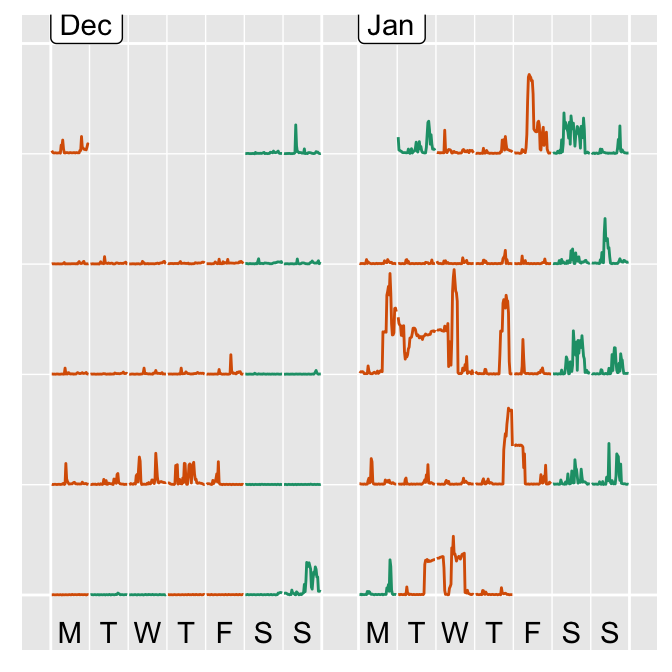

```r
p1 <- elec %>% filter(date < dmy("01022019"), date >= dmy("01122018")) %>% frame_calendar(x = halfhour,
    y = kwh, date = date, ncol = 4) %>% ggplot(aes(x = .halfhour, y = .kwh,
    group = date, colour = factor(work))) + geom_line() + scale_colour_brewer("work",
    palette = "Dark2") + theme(legend.position = "none")
prettify(p1)
```

## Exercise 3: Combine with weather data

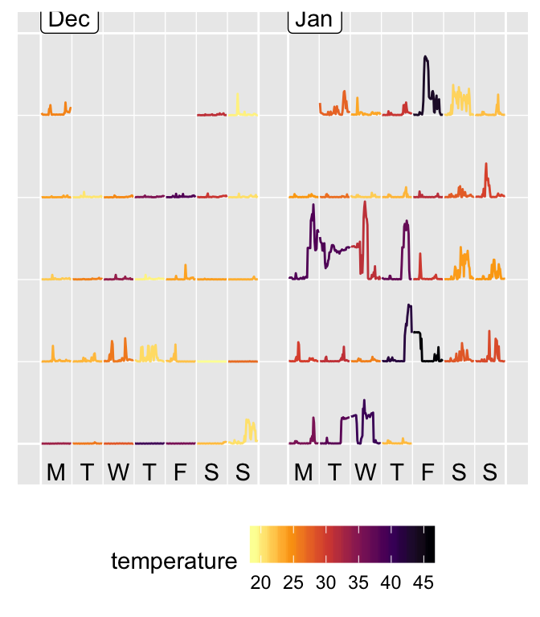

```r
p1 <- elec %>% filter(date < dmy("01022019"), date >= dmy("01122018")) %>% frame_calendar(x = halfhour,
    y = kwh, date = date, ncol = 4) %>% ggplot(aes(x = .halfhour, y = .kwh,
    group = date, colour = Max_temperature)) + geom_line() + scale_colour_viridis_c("temperature",
    option = "inferno", direction = -1) + theme(legend.position = "bottom")
prettify(p1)
```

## Exercise 4: Make a simple plot, and add some interactivity

```r
library(plotly)
p <- elec %>%
  filter(year(date) == 2018) %>%
  group_by(date) %>%
  summarise(kwh = sum(kwh)) %>%
  left_join(maxtemp_DF) %>%
  ggplot(aes(x=Max_temperature, y=kwh, text=date)) + geom_point()
ggplotly(p)
```

[interactive chart not shown]

## Exercise 6: Compare day of the week

```r
p <- elec %>%
  filter(year(date) == 2018) %>%
  group_by(date) %>%
  summarise(kwh = sum(kwh)) %>%
  mutate(wday = wday(date, label = TRUE, week_start = 1)) %>%
  ggplot(aes(x=wday, y=kwh)) + geom_boxplot()
ggplotly(p)
```

[interactive chart not shown]

## Your turn

1. Easy tasks:
   1. Create a test Rmarkdown document
   2. Compile it into an html document
2. Medium task: Create a plot to answer these questions:
   1. What day of the week does the household use more energy? What day of the week is there more variation in energy use?
   2. What time of day does the household wake up? And go to sleep? Is it different on a holiday vs a working day?
   3. Can you guess when Di’s son was home from Uni? Was there a time when the family was away on holidays?
3. Difficult: Make a new app to study energy usage. The steps to do this are:
   1. Run the sample app, and play with changing dates
   2. Add a numerical summary to the output
   3. Make a new tab with a new display, and numerical summary, something that you think is useful to track in energy usage.

## How to win the grand prize

There is a prize for the team that works together the best on the lab activities.

1. Get the best score in the interactive online quiz (after lunch)
2. Produce the most creative web app, with interesting data plots, that someone can use to explore their energy use